# Linear and other classical models for classification on BCI DATA

We will

- load BCI data for classification,
- we will perform a pre-processing of the data,
- run different classifiers on it,
- tune them,
- use a pipeline,
- try Auto ML.

To make it work, you need to install sklearn and astroML on pytyhon 3, for instance by doing  
`pip install -U scikit-learn`  
`pip install -U astroML`  
`pip install auto-sklearn`

## 1. The Problem

### 1.1. Introduction

The brain is an electrochemical organ. All this electrical activity is responsible for different types of brain waves. Throughout the day, the brain keeps active the 5 types of brainwaves (some act at low frequency, others at a higher frequency). Depending on what we do at any given moment, some waves will show greater activity in certain areas of the brain, and others will work less intensely in other regions. None of them will be, in other words, "disconnected." They are:

- Delta waves (1 to 3 Hz) : Delta waves are those that have a higher wavelength and are related to deep sleep (but without dreams) and bodily activities that we are not aware of, such as heart rate regulation or digestion ;
- Theta waves (3.5 to 8 Hz) : is related, above all, to the imaginative capacities, the reflection and the sleep ;
- **Alpha waves (8 to 13 Hz) :** Appear in the midnight dusk where there is calm, but not sleep, where there is relaxation and a favorable state to meditate. A high level of Alpha waves would prevent us from focusing attention ;
- Beta waves (12 to 33 Hz) : Accented by states that are related to the daily activities in which we focus all the attention, when we are alert and we need, at the same time, to be attentive to numerous stimuli.
- Gamma waves (25 to 100 Hz) : This wave is related to tasks of high cognitive processing. They have to do with our learning style, with the ability to record new information, and also with our senses and perceptions, states of happiness and the phases of REM sleep.

Of the 5 waves, 3 of them can be divided into low and high frequencies, because they have strong components in both bands.

Knowing the different types of brain waves allows us to understand the mental processes, emotions, activities and dynamics that generate a type of "energy" in the brain. The Alpha, Beta and Gamma waves are very interesting for recognition of brain states linked to actions, feeling and concentration.

### 1.2. Objective

A classification model that identifies different mental states is desirable. In other words, given a range of possible mental configurations and a set of training data, it is desired to find a model capable of predicting such states from similar data.

Our intention is to compare different models already existing in the literature to observe which models have the best performance in the bci data.

## 2. Description of the data

### 2.1. Introduction

We chose to work with data from the [Kaggle - Synchronized Brainwave Dataset](https://www.kaggle.com/berkeley-biosense/synchronized-brainwave-dataset). This data set consists of an experiment with 30 patients in an experiment where each one was forced to watch a video showing different mental tasks that must be performed. To simplify our methods, we will focus only on the first experiment that is an experiment that measures the level of concentration of a patient when he makes mental calculations of different equations.

### 2.2. Description of the type of methods

We will be working with a binary classification algorithm, since we want to know if the patient is relaxed or concentrated. We will use supervised methods since we already know the output types and we have a set of data already with labels.

### 2.3. Reading, analyzing and separating data

```python
import sys
import json
import pandas as pd
import inspect, os
from os.path import dirname, join as pjoin
```

```python
pathToFile = os.path.dirname(os.path.abspath(inspect.getfile(inspect.currentframe())))
```

```python
data_dir = pjoin(pathToFile, 'synchronized-brainwave-dataset')
csv_fname = pjoin(data_dir, 'eeg-data.csv') # One subject
df = pd.read_csv(csv_fname)
```

```python
# convert to arrays from strings
df.raw_values = df.raw_values.map(json.loads)
```

```python
print('rows: ', df.raw_values.shape)
print('columns: ', len(df.raw_values[0]))
```

```
rows:  (30013,)
columns:  512
```

Tuple containing raw sample values acquired by the sensor, at a sampling rate of 512Hz.

```python
# convert to arrays from strings
df.eeg_power = df.eeg_power.map(json.loads)
```

This one represents the magnitude of 8 commonly-recognized types of EEG frequency bands:

- delta (0.5 - 2.75Hz)
- theta (3.5 - 6.75Hz)
- low-alpha (7.5 - 9.25Hz)
- high-alpha (10 - 11.75Hz)
- low-beta (13 - 16.75Hz)
- high-beta (18 - 29.75Hz)
- low-gamma (31 - 39.75Hz)
- mid-gamma (41 - 49.75Hz)

These values have no units and are only meaningful for comparison to the values for the other frequency bands within a sample.

```python
print("rows: ", df.eeg_power.shape)
print("columns: ", len(df.eeg_power[0]))
```

```
rows:  (30013,)
columns:  8
```

```python
def getMathRelaxData():
    relax = df[df.label == 'relax']
    math = df[(df.label == 'math1') |
              (df.label == 'math2') |
              (df.label == 'math3') |
              (df.label == 'math4') |
              (df.label == 'math5') |
              (df.label == 'math6') |
              (df.label == 'math7') |
              (df.label == 'math8') |
              (df.label == 'math9') |
              (df.label == 'math10') |
              (df.label == 'math11') |
              (df.label == 'math12') ]
    return (relax, math)

(relax,math) = getMathRelaxData()

print('relax: ',len(relax))
print('math: ',len(math))
```

```
relax:  934
math:  936
```

```python
from scipy import stats
from scipy.interpolate import interp1d
import itertools
import numpy as np
```

Each group of 512 raw values produced by the device was taken, and a fast fourier transformation (FFT) was performed to produce a spectrum of energy. Then groups of 3 power spectra are picked up, averaged and the result is logarithmically grouped to produce feature vectors of 100 values.

```python
# Functions
def vector_label (list1):
    def label (l):
        return lambda x: l
    X = list1
    y = list(map(label(0), list1))
    return X, y

def vectors_labels (list1, list2):
    def label (l):
        return lambda x: l
    X = list1 + list2
    y = list(map(label(0), list1)) + list(map(label(1), list2))
    return X, y

def spectrum (vector):
    '''get the power spectrum of a vector of raw EEG data'''
    A = np.fft.fft(vector)
    ps = np.abs(A)**2
    ps = ps[:len(ps)//2]
    return ps

def binned (pspectra, n):
    '''compress an array of power spectra into vectors of length n'''
    l = len(pspectra)
    array = np.zeros([l,n])
    for i,ps in enumerate(pspectra):
        x = np.arange(1,len(ps)+1)
        f = interp1d(x,ps)#/np.sum(ps))
        array[i] = f(np.arange(1, n+1))
    index = np.argwhere(array[:,0]==-1)
    array = np.delete(array,index,0)
    return array

def feature_vector (readings, bins=100): # A function we apply to each group of power spectra
  '''
  Create 100, log10-spaced bins for each power spectrum.
  For more on how this particular implementation works, see:
  http://coolworld.me/pre-processing-EEG-consumer-devices/
  '''
  bins = binned(list(map(spectrum, readings)), bins)
  return np.log10(np.mean(bins, 0))

#ex_readings = one_relax.raw_values[:3]
#feature_vector(ex_readings)

def grouper(n, iterable, fillvalue=None):
    "grouper(3, 'ABCDEFG', 'x') --> ABC DEF Gxx"
    args = [iter(iterable)] * n
    return itertools.zip_longest(*args, fillvalue=fillvalue)

def vectors (df):
    return [feature_vector(group) for group in list(grouper(3, df.raw_values.tolist()))[:-1]]
```

```python
def concatDataFrame(dataFrame,X,y):
    X = np.matrix(X)
    y = np.array(y)
    data = pd.DataFrame(data=X,index=y)
    frames_all_data = [dataFrame, data]
    return pd.concat(frames_all_data)
```

```python
all_data = pd.DataFrame()
math_data = pd.DataFrame()
relax_data = pd.DataFrame()
for id in range(1,31):
    one_math = math[math['id']==id]
    X, y = vector_label(vectors(one_math))
    math_data = concatDataFrame(math_data,X,y)

    one_relax = relax[relax['id']==id]
    X, y = vector_label(vectors(one_relax))
    relax_data = concatDataFrame(relax_data,X,y)

    X, y = vectors_labels(
            vectors(one_math),
            vectors(one_relax))
    all_data = concatDataFrame(all_data,X,y)
```

```python
all_data.index.value_counts()
```

```
1    287
0    284
dtype: int64
```

```python
all_data.info()
```

```
<class 'pandas.core.frame.DataFrame'>
Int64Index: 571 entries, 0 to 1
Data columns (total 100 columns):
0     571 non-null float64
1     571 non-null float64
2     571 non-null float64
3     571 non-null float64
4     571 non-null float64
5     571 non-null float64
6     571 non-null float64
7     571 non-null float64
8     571 non-null float64
9     571 non-null float64
10    571 non-null float64
11    571 non-null float64
```

[output cut: 90 more lines]

```python
all_data.describe().T
```

|  | count | mean | std | min | 25% | 50% | 75% | max |
| --- | --- | --- | --- | --- | --- | --- | --- | --- |
| 0 | 571.0 | 8.718833 | 0.225892 | 7.908061 | 8.642785 | 8.751916 | 8.824803 | 9.945961 |
| 1 | 571.0 | 7.364025 | 0.845245 | 5.173082 | 6.695201 | 7.338237 | 7.901460 | 10.011478 |
| 2 | 571.0 | 7.642200 | 0.864612 | 5.859307 | 6.874756 | 7.667037 | 8.317608 | 10.169244 |
| 3 | 571.0 | 7.633422 | 0.847635 | 5.490494 | 6.910670 | 7.732260 | 8.345504 | 9.740717 |
| 4 | 571.0 | 7.520979 | 0.830876 | 5.390466 | 6.805776 | 7.540616 | 8.239841 | 9.679500 |
| 5 | 571.0 | 7.375221 | 0.782418 | 5.506875 | 6.715224 | 7.374297 | 8.016112 | 9.362660 |
| 6 | 571.0 | 7.276773 | 0.732720 | 5.868444 | 6.700170 | 7.202500 | 7.863743 | 9.444988 |
| 7 | 571.0 | 7.154652 | 0.681531 | 5.732405 | 6.604083 | 7.089735 | 7.664935 | 9.377665 |
| 8 | 571.0 | 7.098325 | 0.614472 | 5.836961 | 6.612619 | 7.080698 | 7.517622 | 8.937194 |
| 9 | 571.0 | 7.103008 | 0.570776 | 5.365616 | 6.696416 | 7.117053 | 7.502337 | 9.117919 |
| 10 | 571.0 | 7.010252 | 0.518133 | 5.264238 | 6.668710 | 7.005532 | 7.363085 | 8.867215 |
| 11 | 571.0 | 6.853588 | 0.501375 | 5.391118 | 6.496418 | 6.831834 | 7.177432 | 8.747649 |
| 12 | 571.0 | 6.696183 | 0.495081 | 5.494469 | 6.356444 | 6.667233 | 7.017438 | 8.795747 |
| 13 | 571.0 | 6.583189 | 0.495374 | 5.305926 | 6.241201 | 6.549791 | 6.879476 | 8.993228 |
| 14 | 571.0 | 6.510233 | 0.474541 | 5.156532 | 6.174036 | 6.470577 | 6.779254 | 8.610311 |
| 15 | 571.0 | 6.448255 | 0.479313 | 5.190811 | 6.129098 | 6.392383 | 6.750981 | 8.265454 |
| 16 | 571.0 | 6.387482 | 0.462884 | 4.839408 | 6.085274 | 6.348457 | 6.657264 | 8.579331 |
| 17 | 571.0 | 6.367323 | 0.456409 | 5.300511 | 6.068013 | 6.317608 | 6.618116 | 8.677849 |
| 18 | 571.0 | 6.369448 | 0.437539 | 5.112962 | 6.085948 | 6.335576 | 6.619735 | 8.459474 |
| 19 | 571.0 | 6.313092 | 0.424319 | 5.145033 | 6.039822 | 6.300906 | 6.568038 | 7.901593 |
| 20 | 571.0 | 6.306382 | 0.409481 | 4.927845 | 6.050650 | 6.268842 | 6.518515 | 7.813841 |
| 21 | 571.0 | 6.294880 | 0.432335 | 4.996889 | 6.018322 | 6.278325 | 6.532557 | 7.895146 |
| 22 | 571.0 | 6.239355 | 0.459047 | 4.314926 | 5.961157 | 6.191881 | 6.491755 | 8.226468 |
| 23 | 571.0 | 6.197505 | 0.460655 | 4.667728 | 5.897374 | 6.178850 | 6.470255 | 8.213929 |
| 24 | 571.0 | 6.184346 | 0.460184 | 4.315427 | 5.898873 | 6.167499 | 6.430192 | 8.296619 |
| 25 | 571.0 | 6.181687 | 0.469917 | 4.826606 | 5.887650 | 6.146978 | 6.438207 | 8.113068 |
| 26 | 571.0 | 6.181190 | 0.462407 | 4.816187 | 5.875484 | 6.170395 | 6.441773 | 7.634236 |
| 27 | 571.0 | 6.153618 | 0.445094 | 4.873516 | 5.855609 | 6.119354 | 6.390596 | 7.740697 |
| 28 | 571.0 | 6.114535 | 0.463567 | 4.695045 | 5.796577 | 6.061403 | 6.376803 | 8.102965 |
| 29 | 571.0 | 6.102608 | 0.480483 | 4.791565 | 5.803297 | 6.048514 | 6.390869 | 7.858750 |
| ... | ... | ... | ... | ... | ... | ... | ... | ... |
| 70 | 571.0 | 5.605803 | 0.490326 | 4.220961 | 5.316095 | 5.546312 | 5.838477 | 7.328376 |
| 71 | 571.0 | 5.634470 | 0.463006 | 4.237744 | 5.339498 | 5.592508 | 5.862296 | 7.532466 |
| 72 | 571.0 | 5.636038 | 0.461152 | 4.240937 | 5.348834 | 5.605709 | 5.881107 | 7.416174 |
| 73 | 571.0 | 5.606203 | 0.493833 | 4.330286 | 5.258925 | 5.562248 | 5.856923 | 7.534779 |
| 74 | 571.0 | 5.624442 | 0.502034 | 3.951792 | 5.336942 | 5.598957 | 5.861396 | 7.638819 |
| 75 | 571.0 | 5.643540 | 0.475893 | 4.312670 | 5.323755 | 5.584095 | 5.914717 | 7.776064 |
| 76 | 571.0 | 5.631152 | 0.474393 | 4.276718 | 5.326246 | 5.594109 | 5.900957 | 7.923062 |
| 77 | 571.0 | 5.623266 | 0.484509 | 3.861298 | 5.331055 | 5.601536 | 5.874244 | 7.863402 |
| 78 | 571.0 | 5.618768 | 0.490130 | 3.786404 | 5.305845 | 5.587427 | 5.876239 | 7.676146 |
| 79 | 571.0 | 5.605568 | 0.478048 | 4.475386 | 5.275490 | 5.544457 | 5.884898 | 7.384065 |
| 80 | 571.0 | 5.607817 | 0.470673 | 4.155793 | 5.312458 | 5.553859 | 5.836391 | 7.290743 |
| 81 | 571.0 | 5.587153 | 0.469889 | 4.322300 | 5.287357 | 5.532728 | 5.853664 | 7.405198 |
| 82 | 571.0 | 5.584410 | 0.494743 | 4.010568 | 5.265345 | 5.551733 | 5.854057 | 7.252179 |
| 83 | 571.0 | 5.611064 | 0.476665 | 4.501271 | 5.297365 | 5.552783 | 5.858912 | 7.524413 |
| 84 | 571.0 | 5.566450 | 0.491011 | 4.232843 | 5.251801 | 5.526748 | 5.840352 | 7.288931 |
| 85 | 571.0 | 5.545431 | 0.474755 | 4.544707 | 5.223169 | 5.490154 | 5.815650 | 7.484567 |
| 86 | 571.0 | 5.533687 | 0.481473 | 4.103333 | 5.243506 | 5.475293 | 5.767008 | 7.599463 |
| 87 | 571.0 | 5.541853 | 0.480323 | 3.897650 | 5.240263 | 5.504367 | 5.780170 | 7.484802 |
| 88 | 571.0 | 5.507707 | 0.478117 | 4.258281 | 5.177929 | 5.477581 | 5.806014 | 7.267069 |
| 89 | 571.0 | 5.537425 | 0.492154 | 4.208339 | 5.228743 | 5.479261 | 5.799784 | 7.213411 |
| 90 | 571.0 | 5.496144 | 0.482050 | 3.908322 | 5.191961 | 5.457016 | 5.774727 | 7.286537 |
| 91 | 571.0 | 5.484994 | 0.521344 | 4.116613 | 5.155437 | 5.432258 | 5.772514 | 7.374176 |
| 92 | 571.0 | 5.467180 | 0.480118 | 4.213976 | 5.160556 | 5.430834 | 5.755559 | 7.134238 |
| 93 | 571.0 | 5.458507 | 0.468731 | 4.039668 | 5.143299 | 5.429977 | 5.727916 | 7.556071 |
| 94 | 571.0 | 5.457625 | 0.473143 | 3.911774 | 5.144741 | 5.440909 | 5.720159 | 7.720318 |
| 95 | 571.0 | 5.438689 | 0.491802 | 3.843261 | 5.100887 | 5.383457 | 5.698027 | 7.540804 |
| 96 | 571.0 | 5.425649 | 0.481042 | 3.723623 | 5.109074 | 5.386232 | 5.696260 | 7.489793 |
| 97 | 571.0 | 5.389315 | 0.490544 | 3.993660 | 5.074887 | 5.337816 | 5.657519 | 7.612932 |
| 98 | 571.0 | 5.392531 | 0.504362 | 3.811613 | 5.068699 | 5.352953 | 5.657518 | 7.459318 |
| 99 | 571.0 | 5.379522 | 0.494818 | 4.131923 | 5.068604 | 5.324554 | 5.676553 | 7.274006 |

100 rows × 8 columns

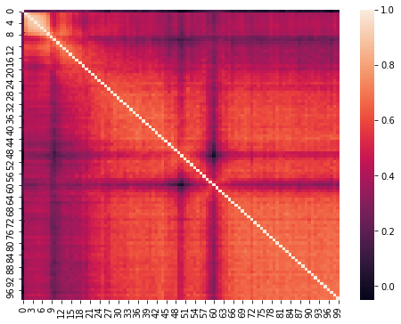

```python
import numpy as np
import seaborn as sns
from sklearn.preprocessing import LabelEncoder, StandardScaler
from sklearn.decomposition import PCA
from sklearn.model_selection import train_test_split, cross_val_score
%pylab inline
corr = all_data.corr()
figsize(8, 6)
sns.heatmap(corr)
```

The class histogram is shown. As there are 100 features, it is a little difficult to see important information, however, it is noticed that all attributes have values greater than zero in both classes.

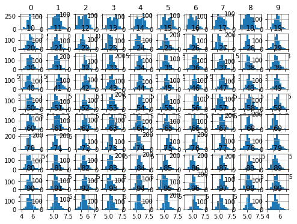

```python
# All_data
plots = all_data.hist()
```

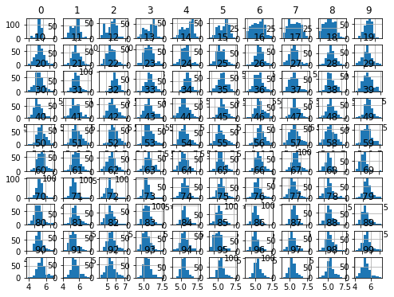

```python
# Math data
plots = math_data.hist()
```

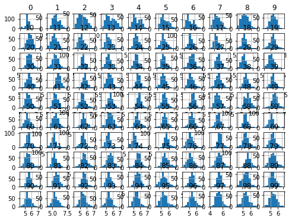

```python
# Relax data
plots = relax_data.hist()
```

The PCA shows that the points fit very close to a common center and after we can see some isolated points many distant from the center points, and possible outliers may be possible.

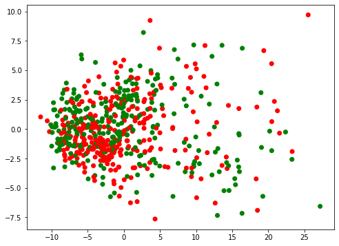

```python
scaler = StandardScaler()
data = scaler.fit_transform(all_data)
pca = PCA(n_components=2)
pca_data = pca.fit_transform(data)
plot_data = all_data
plot_data["relax"] = all_data.index
scatter(pca_data[:, 0], pca_data[:, 1],\
        c=plot_data["relax"].apply(lambda relax: 'red' if relax else 'green'))
```

After the preanalysis and pretreatment, it is necessary to separate the data into training and test sets. As the data is very scarce, it was preferred to follow the procedure performed in the Kaggle forum and to divide it together in training and validation only, because when new data is collected, it will be possible to create a test set and even increase the sets of training and validation. Following this reasoning, you can also compare our models with the forum templates.

```python
from sklearn import preprocessing

(relax,math) = getMathRelaxData()

print('relax: ',len(relax))
print('math: ',len(math))
limit = 20

for i in range(1,limit+1):
    temp_math = math[math['id']==i]
    temp_relax = relax[relax['id']==i]
    if i == 1:
        X_train,y_train = vectors_labels(
            vectors(temp_math),
            vectors(temp_relax))
        X_train = np.asarray(X_train)
        y_train = np.asarray(y_train)
    else:
        X_temp,y_temp = vectors_labels(
            vectors(temp_math),
            vectors(temp_relax))
        X_temp = np.asarray(X_temp)
        y_temp = np.asarray(y_temp)
        X_train = np.concatenate((X_train, X_temp), axis=0)
        y_train = np.concatenate((y_train, y_temp), axis=0)

for i in range(limit+1,31):
    temp_math = math[math['id']==i]
    temp_relax = relax[relax['id']==i]
    if i == (limit+1):
        X_test,y_test = vectors_labels(
            vectors(temp_math),
            vectors(temp_relax))
        X_test = np.asarray(X_test)
        y_test = np.asarray(y_test)
    else:
        X_temp,y_temp = vectors_labels(
            vectors(temp_math),
            vectors(temp_relax))
        X_temp = np.asarray(X_temp)
        y_temp = np.asarray(y_temp)
        X_test = np.concatenate((X_test, X_temp), axis=0)
        y_test = np.concatenate((y_test, y_temp), axis=0)
```

```
relax:  934
math:  936
```

```python
print(X_train.shape)
print(X_test.shape)
```

```
(369, 100)
(202, 100)
```

## 3. Other Results

### 3.1. Introduction

In this section we will talk about results already obtained by other people with the same data. On the site [Kaggle - Synchronized Brainwave Dataset](https://www.kaggle.com/berkeley-biosense/synchronized-brainwave-dataset), several people have posted their codes with their results so that everyone could see and reuse the code, but only two posts are really interesting for us:

### 3.2. Classifying relaxation versus doing math

The interesting thing about this code is the choice of the data that is preprocessed using the Fourier transform, averaging groups of 3 power spectra and logarithmically grouping the result to produce feature vectors of 100 values.

The problem with the code was that the author only used one person as a training set and another as a test, so he does not have a robust model.

### 3.3. Math/relax prediction with different classifiers

This one is really very well done. He used 8 possible brain waves as attributes, much less than the 512 attributes of raw data. Other than that, the author performed a good analysis of the data and tested different methods on the data. He got to get 0.64280936454849502 of precision with SVC.

## 4. Our methods

### 4.1. Introduction

In this section, we will use different literature methods to compare different models. The most intriguing part of this section was not only to have a response to the given data set, but to create a method that can easily be reapplied in different bci datasets.

### 4.2. The classes

Basically, we're going to work with 2 classes:

- BCIBinaryClassifierModel ;
- BCIBinaryClassifierModelCrossValidation.

The first class is to have and manage different classification methods, as well as their performances in a given data set, besides being able to organize the values in a results table.

The second class has as input a first class object and a list of parameters (if not given, it has a standard list), and perform a cross-validation to find out the best parameter for each method.

```python
#==============================================================================
# Class created to facilitate the execution and comparison of different methods
# on bci data
#==============================================================================

#============================Basic Import===========================================

import json
import pandas as pd
import numpy as np
import scipy.io as sio
from sklearn.model_selection import cross_val_score
from sklearn import svm
from scipy import stats
from scipy.interpolate import interp1d
import itertools
import numpy as np
from sklearn import preprocessing
from IPython.display import display, HTML

#============================Import to the Naive bayes classifier===========================================
from sklearn import naive_bayes
from sklearn.naive_bayes import GaussianNB
from sklearn import metrics
from sklearn.metrics import confusion_matrix

#============================Import to the LDA===========================================
from sklearn.discriminant_analysis import LinearDiscriminantAnalysis

#============================Import to the QDA===========================================
from sklearn.discriminant_analysis import QuadraticDiscriminantAnalysis

#============================Import to the Logistic Regression===========================================
from sklearn.linear_model import LogisticRegression

#============================Import to the GMM===========================================
from sklearn.mixture import GaussianMixture

#============================Import to the KNN===========================================
from sklearn.neighbors import KNeighborsClassifier
from sklearn.model_selection import train_test_split
from sklearn.model_selection import GridSearchCV
import time

#============================Import to the simple classification pipeline
# and pipeline + hyperparameter tuning ===========================================
from sklearn.svm import LinearSVC
from sklearn.feature_selection import SelectKBest
from sklearn.feature_selection import f_regression
from sklearn.pipeline import Pipeline

#============================Import to the SVM linear===========================================
from sklearn.svm import LinearSVC

#============================Import to the Random Forest and AdaBoost===========================================
from sklearn.ensemble import RandomForestClassifier, AdaBoostClassifier

#============================Import to the Kernelized SVM===========================================
from sklearn.svm import SVC

#============================Import to the AutoML===========================================
#import warnings
#warnings.filterwarnings("ignore")
#
#import autosklearn.classification
#import sklearn.model_selection
#import sklearn.datasets
#import sklearn.metrics
#
#from autosklearn.metrics import make_scorer



#============================Class===========================================
class GMMBayes(object):
    def fit(X,y,n_components = 3,gmm_tol=0.1,gmm_covariance_type = 'full'):
        model_class_0 = GaussianMixture(n_components=n_components, tol = gmm_tol,covariance_type  = gmm_covariance_type )
        model_class_0.fit(X[np.nonzero(y<0.5)[0],:])
        model_class_1 = GaussianMixture(n_components=n_components, tol = gmm_tol,covariance_type  = gmm_covariance_type )
        model_class_1.fit(X[np.nonzero(y>0.5)[0],:])
        p0 = np.sum(y == 0)/len(y)
        p1 = np.sum(y == 1)/len(y)
        return(model_class_0,model_class_1,p0,p1)

    def predict(X,m0,m1,p0,p1):
        Z_0 = m0.score_samples(X)
        Z_1 = m1.score_samples(X)
        y_p = (Z_0 + np.log(p0)) < (Z_1 + np.log(p1))
        return(y_p)

def my_knn(Xl, yl, Xv, yv, k):
            neigh = KNeighborsClassifier(n_neighbors=k)
            neigh.fit(Xl, yl)
            y_p = neigh.predict(Xv)

            TP = np.sum((y_p == 1) & (yv == 1))  # true positives
            FP = np.sum((y_p == 1) & (yv == 0))  # false positives
            FN = np.sum((y_p == 0) & (yv == 1))  # false negatives
            TN = np.sum((y_p == 0) & (yv == 0))  # false negatives

            p = TP / (TP + FP)
            r = TP / (TP + FN)
            F1 = 2*p*r/(p+r)
            return F1

class BCIBinaryClassifierModel: # Test == Validation



    def __init__(self,x_train,y_train,x_test,y_test,class1name,class2name,printResults):
        self.x_train = x_train
        self.y_train = y_train
        self.x_test = x_test
        self.y_test = y_test

        self.class1name = class1name
        self.class2name = class2name

        self.printResults = printResults

        self.cf_nbc = None
        self.cf_lda = None
        self.cf_qda = None
        self.cf_lr = None
        self.cf_gmm = None
        self.cf_gmmbayes = None
        self.cf_knn = None
        self.cf_knncross = None
        self.cf_knn_gs = None
        self.cf_ppl = None
        self.cf_pp = None
        self.cf_svmlinear = None
        self.cf_svcgrid = None
        self.cf_rf = None
        self.cf_boost = None
        self.cf_svmkernel = None
        self.cf_auto = None

    def naive_bayes_classifier(self):
        model_nb = naive_bayes.GaussianNB()
        model_nb.fit(self.x_train, self.y_train)
        y_pred_nb = model_nb.predict(self.x_test)

        self.cf_nbc = confusion_matrix(self.y_test, y_pred_nb)*100/len(self.y_test)
        if self.printResults:
            print(self.cf_nbc)
            print(metrics.classification_report(self.y_test, y_pred_nb, target_names=[self.class1name, self.class2name]))
        return self.cf_nbc

    def lda(self,lda_solver="svd"):
        model_lda = LinearDiscriminantAnalysis(solver=lda_solver, store_covariance=True)
        y_pred_lda = model_lda.fit(self.x_train, self.y_train).predict(self.x_test)
        y_pred_lda = model_lda.predict(self.x_test)

        self.cf_lda = confusion_matrix(self.y_test, y_pred_lda)*100/len(self.y_test)
        if self.printResults:
            print(self.cf_lda)
            print(metrics.classification_report(self.y_test, y_pred_lda, target_names=[self.class1name, self.class2name]))
        return self.cf_lda
```

```python
    def qda(self, qda_reg_param = 0):
        model_qda = QuadraticDiscriminantAnalysis(reg_param = qda_reg_param,store_covariance=True)
        y_pred_qda = model_qda.fit(self.x_train, self.y_train).predict(self.x_test)
        y_pred_qda = model_qda.predict(self.x_test)

        cf_qda = confusion_matrix(self.y_test, y_pred_qda)*100/len(self.y_test)
        if self.printResults:
            print(cf_qda)
            print(metrics.classification_report(self.y_test, y_pred_qda, target_names=[self.class1name, self.class2name]))
        return cf_qda

    def logistic_regression(self,lr_penalty = 'l2',lr_solver = 'liblinear'):
        model_log_reg = LogisticRegression(penalty = lr_penalty, solver = lr_solver).fit(self.x_train, self.y_train)
        y_proba_lr = model_log_reg.predict_proba(self.x_test)
        y_pred_lr = np.argmax(y_proba_lr,1)

        self.cf_lr = confusion_matrix(self.y_test, y_pred_lr)*100/len(self.y_test)
        if self.printResults:
            print(self.cf_lr)
            print(metrics.classification_report(self.y_test, y_pred_lr, target_names=[self.class1name, self.class2name]))
        return self.cf_lr

    def GMM(self,gmm_n_coponents = 3, gmm_tol = 0.1, gmm_covariance_type = 'full'):
        # regularization by eary stopping
        model_class_0 = GaussianMixture(n_components=gmm_n_coponents, tol = gmm_tol,covariance_type = gmm_covariance_type)
        model_class_0.fit(self.x_train[np.nonzero(self.y_train<0.5)[0],:])
        model_class_1 = GaussianMixture(n_components=gmm_n_coponents, tol = gmm_tol,covariance_type = gmm_covariance_type)
        model_class_1.fit(self.x_train[np.nonzero(self.y_train>0.5)[0],:])
        pr_0 = np.sum(self.y_train == 0)/len(self.y_train)
        pr_1 = np.sum(self.y_train == 1)/len(self.y_train)

        Z_0 = model_class_0.score_samples(self.x_test)
        Z_1 = model_class_1.score_samples(self.x_test)

        y_pred_gmm = Z_0 - Z_1 < np.log(pr_1) - np.log(pr_0)

        self.cf_gmm = confusion_matrix(self.y_test, y_pred_gmm)*100/len(self.y_test)
        if self.printResults:
            print(self.cf_gmm)
            print(metrics.classification_report(self.y_test, y_pred_gmm, target_names=[self.class1name, self.class2name]))
        return self.cf_gmm

    def GMM_Bayes(self,n_components = 3,gmm_tol=0.1,gmm_covariance_type='full'):
        m0,m1,p0,p1 = GMMBayes.fit(self.x_train, self.y_train,n_components,gmm_tol,gmm_covariance_type)
        y_pred = GMMBayes.predict(self.x_test,m0,m1,p0,p1)

        self.cf_gmmbayes = confusion_matrix(self.y_test, y_pred)*100/len(self.y_test)
        if self.printResults:
            print(self.cf_gmmbayes)
            print(metrics.classification_report(self.y_test, y_pred, target_names=[self.class1name, self.class2name]))
        return self.cf_gmmbayes

    def KNN(self,knn_n_neighbors=3):
        neigh = KNeighborsClassifier(n_neighbors=knn_n_neighbors)
        neigh.fit(self.x_train, self.y_train)
        y_pred = neigh.predict(self.x_test)

        self.cf_knn = confusion_matrix(self.y_test, y_pred)*100/len(self.y_test)
        if self.printResults:
            print(self.cf_knn)
            print(metrics.classification_report(self.y_test, y_pred, target_names=[self.class1name, self.class2name]))
        return self.cf_knn

    def KNN_CrossV(self,kmax, knn_test_size = 0.66, knn_random_state=42,getBestK=False):
        X_train_v, X_valid, y_train_v, y_valid = train_test_split(self.x_train, self.y_train, test_size=knn_test_size, random_state=knn_random_state)
        f1 = np.zeros(kmax)
        for k in range(1,kmax+1):
            f1[k-1] = my_knn(X_train_v, y_train_v, X_valid, y_valid, k)
            if self.printResults:
                print(k)
                print(f1[k-1])

        k = np.argmax(f1)+1
        neigh = KNeighborsClassifier(n_neighbors=k)
        neigh.fit(self.x_train, self.y_train)
        y_pred = neigh.predict(self.x_test)

        self.cf_knncross = confusion_matrix(self.y_test, y_pred)*100/len(self.y_test)
        if self.printResults:
            print(self.cf_knncross)
            print(metrics.classification_report(self.y_test, y_pred, target_names=[self.class1name, self.class2name]))
        if(getBestK):
            return (k,self.cf_knncross)
        else:
            return self.cf_knncross

    def KNN_Grid_Search(self,knn_neighbors=[1, 2, 3, 4, 5 ,6 ,7]):
        param_grid = [
          {'n_neighbors': knn_neighbors},
         ]

        clf = GridSearchCV(KNeighborsClassifier(), param_grid, cv=2,
                               scoring='%s_macro' % 'f1')
        t0=time.time()
        clf.fit(self.x_train, self.y_train)
        if self.printResults:
            print('total computing time: '+str(time.time()-t0))

            print("Best parameters set found on development set:")
            print(clf.best_params_)

        k = clf.best_params_['n_neighbors']
        y_pred = clf.predict(self.x_test)

        self.cf_knn_gs = confusion_matrix(self.y_test, y_pred)*100/len(self.y_test)
        if self.printResults:
            print(self.cf_knn_gs)
            print(metrics.classification_report(self.y_test, y_pred, target_names=[self.class1name, self.class2name]))
        return self.cf_knn_gs

    def simple_classification_pipeline(self,anovaks = 3,svcc = .1):
        anova_filter = SelectKBest()
        clf = LinearSVC()

        anova_svm = Pipeline([('anova', anova_filter), ('svc', clf)])

        t0=time.time()
        anova_svm.set_params(anova__k=anovaks, svc__C=svcc).fit(self.x_train, self.y_train)
        if self.printResults:
            print('total computing time: %5.2f sec' % (time.time()-t0))

        y_pred_ppl = anova_svm.predict(self.x_test)
        self.cf_ppl = confusion_matrix(self.y_test, y_pred_ppl)*100/len(self.y_test)

        if self.printResults:
            print(self.cf_ppl)
            print(metrics.classification_report(self.y_test, y_pred_ppl, target_names=[self.class1name, self.class2name]))
        return self.cf_ppl
```

```python
    def pipeline_hyperparameter_tuning(self,anovak=[3, 4],knn_n_neighbors=[4, 6],returnBest=False):
        pipe = Pipeline(memory=None,
         steps=[('anova', SelectKBest()),
                ('knn', KNeighborsClassifier())]
               )
        param_grid = {
            'anova__k': anovak,
            'knn__n_neighbors': knn_n_neighbors,
        }

        search = GridSearchCV(pipe, param_grid, iid=False, cv=2,  # should be 5
                              return_train_score=False)
        t0=time.time()
        search.fit(self.x_train, self.y_train)
        if self.printResults:
            print('total computing time: %5.2f sec' % (time.time()-t0))

            print("Best parameter (CV score=%0.3f):" % search.best_score_)
            print(search.best_params_)

        y_pred_ppl = search.predict(self.x_test)
        self.cf_pp = confusion_matrix(self.y_test, y_pred_ppl)*100/len(self.y_test)
        if self.printResults:
            print(self.cf_pp)
            print(metrics.classification_report(self.y_test, y_pred_ppl, target_names=[self.class1name, self.class2name]))
        if returnBest:
            return (search.best_params_.values(),self.cf_pp)
        else:
            return self.cf_pp


    def svm_linear(self,svmC = 1.0):
        clf = LinearSVC(C = svmC)
        clf.fit(self.x_train, self.y_train)
        y_pred = clf.predict(self.x_test)

        self.cf_svmlinear = confusion_matrix(self.y_test, y_pred)*100/len(self.y_test)
        if self.printResults:
            print(self.cf_svmlinear)
            print(metrics.classification_report(self.y_test, y_pred, target_names=[self.class1name, self.class2name]))
        return self.cf_svmlinear

    def svm_linear_grid(self,svmgridC = [.01, .05, 0.075, .1, .15, .2, .5, 1, 5, 10]):
        param_grid = [
          {'C': svmgridC},
         ]

        clf = GridSearchCV(LinearSVC(dual=True, fit_intercept=True, intercept_scaling=1,
              loss='hinge', penalty='l2', tol=0.01), param_grid, cv=2,
                               scoring='%s_macro' % 'f1')
        clf.fit(self.x_train, self.y_train)

        if self.printResults:
            print("Best parameters set found on development set:")
            print(clf.best_params_)

        Copt = clf.best_params_['C']
        clf = LinearSVC(C=Copt, dual=True, fit_intercept=True, intercept_scaling=1,
              loss='hinge', penalty='l2', tol=0.01)
        clf.fit(self.x_train, self.y_train)
        y_pred = clf.predict(self.x_test)

        self.cf_svcgrid = confusion_matrix(self.y_test, y_pred)*100/len(self.y_test)
        if self.printResults:
            print(self.cf_svcgrid)
            print(metrics.classification_report(self.y_test, y_pred, target_names=[self.class1name, self.class2name]))
        return self.cf_svcgrid

    def random_forest(self, rf_max_depth = 5,rf_n_estimators = 10, rf_max_features = 1):
        model_rf = RandomForestClassifier(max_depth=rf_max_depth, n_estimators=rf_n_estimators, max_features=rf_max_features)
        model_rf.fit(self.x_train, self.y_train)
        y_pred = model_rf.predict(self.x_test)

        self.cf_rf = confusion_matrix(self.y_test, y_pred)*100/len(self.y_test)
        if self.printResults:
            print('RF')
            print(self.cf_rf)
            print(metrics.classification_report(self.y_test, y_pred, target_names=[self.class1name, self.class2name]))
        return self.cf_rf

    def AdaBoost(self,ada_n_estimators=200):
        model_ab =  AdaBoostClassifier(n_estimators=ada_n_estimators)
        model_ab.fit(self.x_train, self.y_train)
        y_pred = model_ab.predict(self.x_test)

        self.cf_boost = confusion_matrix(self.y_test, y_pred)*100/len(self.y_test)
        if self.printResults:
            print('AdaBoost')
            print(self.cf_boost)
            print(metrics.classification_report(self.y_test, y_pred, target_names=[self.class1name, self.class2name]))
        return self.cf_boost

    def kernelized_svm(self,svmGamma = 2,svmC = 1,svmkernel = 'rbf',):
        model_svm = SVC(gamma=svmGamma, C=svmC,kernel = svmkernel)
        t0=time.time()
        model_svm.fit(self.x_train, self.y_train)
        if self.printResults:
            print('total computing time: %5.2f sec' % (time.time()-t0))
        y_pred = model_svm.predict(self.x_test)

        self.cf_svmkernel = confusion_matrix(self.y_test, y_pred)*100/len(self.y_test)
        if self.printResults:
            print('SMV')
            print(self.cf_svmkernel)
            print(metrics.classification_report(self.y_test, y_pred, target_names=[self.class1name, self.class2name]))
        return self.cf_svmkernel

    def automl(self):
        import warnings
        warnings.filterwarnings("ignore")
        import autosklearn.classification
        import sklearn.model_selection
        import sklearn.datasets
        import sklearn.metrics
        from autosklearn.metrics import make_scorer

        automl = autosklearn.classification.AutoSklearnClassifier(
             time_left_for_this_task=267800,
                 per_run_time_limit=1276,
             exclude_estimators=None,
        #     include_preprocessors=["no_preprocessing", ],
             exclude_preprocessors=None)

        scorer = autosklearn.metrics.make_scorer(
                'f1_score',
                sklearn.metrics.f1_score,
                pos_label=1,
            )

        automl.fit(self.x_train, self.y_train, metric=scorer)

        y_pred = automl.predict(self.x_test)
        self.cf_auto = confusion_matrix(self.y_test, y_pred)*100/len(self.y_test)
        print(self.cf_auto)
        print(metrics.classification_report(self.y_test, y_pred, target_names=[self.class1name, self.class2name]))
        return self.cf_auto

    def showResults(self):

        res = pd.DataFrame(index=["Precision on a test set"])
        if(self.cf_nbc is not None): res.loc[:, 'Naive bayes classifier'] = (self.cf_nbc[0,0]+self.cf_nbc[1,1])
        if(self.cf_lda is not None): res.loc[:, 'LDA'] = (self.cf_lda[0,0]+self.cf_lda[1,1])
        if(self.cf_qda is not None): res.loc[:, 'QDA'] = (self.cf_qda[0,0]+self.cf_qda[1,1])
        if(self.cf_lr is not None): res.loc[:, 'Logistic regression'] = (self.cf_lr[0,0]+self.cf_lr[1,1])
        if(self.cf_gmm is not None): res.loc[:, 'Mixture model'] =  (self.cf_gmm[0,0]+self.cf_gmm[1,1])
        if(self.cf_gmmbayes is not None): res.loc[:, 'Mixture model Bayes'] =  (self.cf_gmmbayes[0,0]+self.cf_gmmbayes[1,1])
        if(self.cf_knn is not None): res.loc[:, 'k nearest neighbors'] = (self.cf_knn[0,0]+self.cf_knn[1,1])
        if(self.cf_knncross is not None): res.loc[:, 'k nearest neighbors Cross Validation'] = (self.cf_knncross[0,0]+self.cf_knncross[1,1])
        if(self.cf_knn_gs is not None): res.loc[:, 'k nearest neighbors Grid'] = (self.cf_knn_gs[0,0]+self.cf_knn_gs[1,1])
        display(res)
```

```python
        res = pd.DataFrame(index=["Precision on a test set"])
        if(self.cf_ppl is not None): res.loc[:, 'Pipeline '' VS_knn'] =  (self.cf_ppl[0,0]+self.cf_ppl[1,1])
        if(self.cf_pp is not None): res.loc[:, 'Pipeline + HP_tuning'] = (self.cf_pp[0,0]+self.cf_pp[1,1])
        if(self.cf_svmlinear is not None): res.loc[:, 'Linear SVM Linear'] = (self.cf_svmlinear[0,0]+self.cf_svmlinear[1,1])
        if(self.cf_svcgrid is not None): res.loc[:, 'Linear SVM Grid'] = (self.cf_svcgrid[0,0]+self.cf_svcgrid[1,1])
        if(self.cf_rf is not None): res.loc[:, 'Random Forest'] = (self.cf_rf[0,0]+self.cf_rf[1,1])
        if(self.cf_boost is not None): res.loc[:, 'Ada Boost'] =  (self.cf_boost[0,0]+self.cf_boost[1,1])
        if(self.cf_svmkernel is not None): res.loc[:, 'Kernel SVM']  = (self.cf_svmkernel[0,0]+self.cf_svmkernel[1,1])
        #if(self.cf_auto is not None): res.loc[:, 'Auto ML'] = (self.cf_auto[0,0]+self.cf_auto[1,1])
        display(res)

        if(self.cf_auto is not None):
            res = pd.DataFrame(index=["Precision on a test set"])
            res.loc[:, 'AutoML'] =  (self.cf_auto[0,0]+self.cf_auto[1,1])
            display(res)
```

```python
class BCIBinaryClassifierModelCrossValidation:

    lda_param = (['svd','lsqr','eigen'],)
    qda_param = (np.linspace(0.0, 1.0, num=20),)
    ldr_param = (['l1','l2'],['newton-cg', 'lbfgs', 'liblinear', 'sag', 'saga'])
    gmm_param = ([int(x) for x in range(1,10)],np.linspace(0.0, 1.0, num=10),['full', 'tied', 'diag', 'spherical'])
    gmm_bayes_param = ([int(x) for x in range(1,10)],np.linspace(0.0, 1.0, num=10),['full', 'tied', 'diag', 'spherical'])
    knn_param = ([0.44,0.55,0.66],[10,25,42])
    knn_gs_param = ([int(x) for x in range(1,100)],)
    ppl_param = ([int(x) for x in range(1,10)] + [int(x) for x in range(20,101,10)],[0.0001,0.001,0.01,0.1,1,10,100,1000,100000])
    pp_param = ([int(x) for x in range(1,10)] + [int(x) for x in range(20,101,10)],[int(x) for x in range(1,100)])
    svmlinear_param = ([0.0001,0.001,0.01,0.1,1,10,100,1000,100000],)
    svmlinear_grid_param = ([0.0001,0.001,0.01,.05, 0.075, .1, .15, .2, .5, 1, 5,10,100,1000,100000],)
    forest_param = ([1,10,100,200],[1,10,100,1000,2000],[10,40,80])
    boost_param = ([int(x) for x in range(1,250)],)
    svmkernel_param = ([2,1,.1,0.05,1.0/99],[0.0001,0.001,0.01,0.1,1,10,100,1000,100000],['linear', 'poly', 'rbf', 'sigmoid'])

    def __init__(self,x_train,y_train,x_test,y_test,class1name,class2name):
        self.x_train = x_train
        self.y_train = y_train
        self.x_test = x_test
        self.y_test = y_test

        self.class1name = class1name
        self.class2name = class2name

        self.bci_model = BCIBinaryClassifierModel(x_train,y_train,x_test,y_test,class1name,class2name,False)

        self.cf_nbc = None

        self.cf_lda = None
        self.lda_best_param = None

        self.cf_qda = None
        self.qda_best_param = None

        self.cf_lr = None
        self.lr_best_param = None

        self.cf_gmm = None
        self.gmm_best_param = None

        self.cf_gmmbayes = None
        self.gmm_bayes_best_param = None

        self.cf_knn = None

        self.cf_knncross = None
        self.knncross_best_param = None

        self.cf_knn_gs = None
        self.knn_gs_best_param = None

        self.cf_ppl = None
        self.ppl_best_param = None

        self.cf_pp = None
        self.pp_best_param = None

        self.cf_svmlinear = None
        self.svmlinear_best_param = None

        self.cf_svcgrid = None

        self.cf_rf = None
        self.forest_best_param = None

        self.cf_boost = None
        self.boost_best_param = None

        self.cf_svmkernel = None
        self.svmkernel_best_param = None

        self.cf_auto = None

    def naive_bayes_classifier(self):
        self.cf_nbc = self.bci_model.naive_bayes_classifier()
        print(self.cf_nbc)
        print("precision: ",(self.cf_nbc[0,0]+self.cf_nbc[1,1]))
        return self.cf_nbc

    def lda(self,solvers = lda_param[0]):
        cm_lda_matrix = []
        cm_lda_prescision = []
        for solver in solvers:
            cm_lda_temp = self.bci_model.lda(solver)
            cm_lda_matrix.append(cm_lda_temp)
            cm_lda_prescision.append(cm_lda_temp[0,0]+cm_lda_temp[1,1])

        index_of_best = cm_lda_prescision.index(max(cm_lda_prescision))
        self.lda_best_param = str(dict( zip(['solvers'],solvers[index_of_best]) ))
        self.cm_lda = cm_lda_matrix[index_of_best]
        print(self.cm_lda)
        print("precision: ",(self.cm_lda[0,0]+self.cm_lda[1,1]))
        print("Best param: solver = "+self.lda_best_param)
        return self.cm_lda

    def qda(self,qda_reg_param = qda_param[0]):
        cm_qda_matrix = []
        cm_qda_prescision = []
        for reg_param in qda_reg_param:
            cm_qda_temp = self.bci_model.qda(reg_param)
            cm_qda_matrix.append(cm_qda_temp)
            cm_qda_prescision.append(cm_qda_temp[0,0]+cm_qda_temp[1,1])

        index_of_best = cm_qda_prescision.index(max(cm_qda_prescision))
        self.qda_best_param = str( dict( zip(['qda_reg_param'] ,[ qda_reg_param[index_of_best] ]) ) )
        self.cm_qda = cm_qda_matrix[index_of_best]
        print(self.cm_qda)
        print("precision: ",(self.cm_qda[0,0]+self.cm_qda[1,1]))
        print("Best param: solver = "+str(self.qda_best_param))
        return self.cm_qda

    def logistic_regression(self,lr_penaltys=ldr_param[0],lr_solvers=ldr_param[1]):
        cm_lr_matrix = []
        cm_lr_prescision = []
        possibles_param = []
        for penalty in lr_penaltys:
            for solver in lr_solvers:
                if penalty == 'l1' and (solver == 'newton-cg' or solver == 'lbfgs' or solver == 'sag'):
                    continue
                cm_lr_temp = self.bci_model.logistic_regression(penalty,solver)
                cm_lr_matrix.append(cm_lr_temp)
                cm_lr_prescision.append(cm_lr_temp[0,0]+cm_lr_temp[1,1])
                possibles_param.append((penalty,solver))

        index_of_best = cm_lr_prescision.index(max(cm_lr_prescision))
        self.lr_best_param = str( dict( zip( ['lr_penaltys','lr_solvers'] , possibles_param[index_of_best] ) ) )
        self.cf_lr = cm_lr_matrix[index_of_best]
        print(self.cf_lr)
        print("precision: ",(self.cf_lr[0,0]+self.cf_lr[1,1]))
        print("Best param: solver = "+str(self.lr_best_param))
        return self.cf_lr

    def GMM(self,gmm_n_components=gmm_param[0],gmm_tol=gmm_param[1],gmm_cov_type=gmm_param[2]):
        cm_gmm_matrix = []
        cm_gmm_prescision = []
        possibles_param = []
        for n_components in gmm_n_components:
            for tol in gmm_tol:
                for cov_type in gmm_cov_type:
                    cm_gmm_temp = self.bci_model.GMM(n_components,tol,cov_type)
                    cm_gmm_matrix.append(cm_gmm_temp)
                    cm_gmm_prescision.append(cm_gmm_temp[0,0]+cm_gmm_temp[1,1])
                    possibles_param.append((n_components,tol,cov_type))

        index_of_best = cm_gmm_prescision.index(max(cm_gmm_prescision))
        self.gmm_best_param = str( dict( zip( ['gmm_n_components','gmm_tol','gmm_cov_type'] ,
                                        possibles_param[index_of_best] ) ) )
        self.cf_gmm = cm_gmm_matrix[index_of_best]
        print(self.cf_gmm)
        print("precision: ",(self.cf_gmm[0,0]+self.cf_gmm[1,1]))
        print("Best param: solver = "+str(self.gmm_best_param))
        return self.cf_gmm
```

```python
    def GMM_Bayes(self,gmm_bayes_n_components=gmm_bayes_param[0],gmm_bayes_tol=gmm_bayes_param[1],gmm_bayes_cov_type=gmm_bayes_param[2]):
        cm_gmm_bayes_matrix = []
        cm_gmm_bayes_prescision = []
        possibles_param = []
        for n_components in gmm_bayes_n_components:
            for tol in gmm_bayes_tol:
                for cov_type in gmm_bayes_cov_type:
                    cm_gmm_bayes_temp = self.bci_model.GMM_Bayes(n_components,tol,cov_type)
                    cm_gmm_bayes_matrix.append(cm_gmm_bayes_temp)
                    cm_gmm_bayes_prescision.append(cm_gmm_bayes_temp[0,0]+cm_gmm_bayes_temp[1,1])
                    possibles_param.append((n_components,tol,cov_type))

        index_of_best = cm_gmm_bayes_prescision.index(max(cm_gmm_bayes_prescision))
        self.gmm_bayes_best_param = str( dict( zip( ['gmm_bayes_n_components','gmm_bayes_tol','gmm_bayes_cov_type'],
                                              possibles_param[index_of_best] ) ) )
        self.cf_gmmbayes = cm_gmm_bayes_matrix[index_of_best]
        print(self.cf_gmmbayes)
        print("precision: ",(self.cf_gmmbayes[0,0]+self.cf_gmmbayes[1,1]))
        print("Best param: solver = "+str(self.gmm_bayes_best_param))
        return self.cf_gmmbayes

    def KNN(self):
        self.cf_knn = self.bci_model.KNN()
        print(self.cf_knn)
        print("precision: ",(self.cf_knn[0,0]+self.cf_knn[1,1]))
        return self.cf_knn

    def KNN_CrossV(self,kmax=100,knntest_size=knn_param[0],knn_random = knn_param[1]):
        cm_knncross_matrix = []
        cm_knncross_prescision = []
        possibles_param = []
        for test_size in knntest_size:
            for random_state in knn_random:
                cm_knncross_temp = self.bci_model.KNN_CrossV(kmax, test_size, random_state,True)
                cm_knncross_matrix.append(cm_knncross_temp[1])
                cm_knncross_prescision.append(cm_knncross_temp[1][0,0]+cm_knncross_temp[1][1,1])
                possibles_param.append((cm_knncross_temp[0],test_size,random_state))

        index_of_best = cm_knncross_prescision.index(max(cm_knncross_prescision))
        self.knncross_best_param = str( dict( zip( ['knntest_size','knn_random','random_state'],
                                             possibles_param[index_of_best] ) ) )
        self.cf_knncross = cm_knncross_matrix[index_of_best]
        print(self.cf_knncross)
        print("precision: ",(self.cf_knncross[0,0]+self.cf_knncross[1,1]))
        print("Best param: solver = "+str(self.knncross_best_param))
        return self.cf_knncross

    def KNN_Grid_Search(self,knn_gs_neighbors=knn_gs_param[0]):
        self.cf_knn_gs = self.bci_model.KNN_Grid_Search(knn_gs_neighbors)
        print(self.cf_knn_gs)
        print("precision: ",(self.cf_knn_gs[0,0]+self.cf_knn_gs[1,1]))
        return self.cf_knn_gs

    def simple_classification_pipeline(self,anovak = ppl_param[0],svcc = ppl_param[1]):
        cm_ppl_matrix = []
        cm_ppl_prescision = []
        possibles_param = []
        for k in anovak:
            for c in svcc:
                cm_ppl_temp = self.bci_model.simple_classification_pipeline(k,c)
                cm_ppl_matrix.append(cm_ppl_temp)
                cm_ppl_prescision.append(cm_ppl_temp[0,0]+cm_ppl_temp[1,1])
                possibles_param.append((k,c))

        index_of_best = cm_ppl_prescision.index(max(cm_ppl_prescision))
        self.ppl_best_param = str( dict( zip( ['anova k','svcc'] ,possibles_param[index_of_best] ) ) )
        self.cf_ppl = cm_ppl_matrix[index_of_best]
        print(self.cf_ppl)
        print("precision: ",(self.cf_ppl[0,0]+self.cf_ppl[1,1]))
        print("Best param: solver = "+str(self.ppl_best_param))
        return self.cf_ppl

    def pipeline_hyperparameter_tuning(self,anovak=pp_param[0],n_neighbors = pp_param[1]):
        (best_param_temp,self.cf_pp) = self.bci_model.pipeline_hyperparameter_tuning(anovak,n_neighbors,True)
        self.pp_best_param = str( dict( zip( ['anova k','n_neighbors'] , best_param_temp ) ) )
        print(self.cf_pp)
        print("precision: ",(self.cf_pp[0,0]+self.cf_pp[1,1]))
        return self.cf_pp


    def svm_linear(self,svmC = svmlinear_param[0]):
        cm_svmlinear_matrix = []
        cm_svmlinear_prescision = []
        possibles_param = []
        for C in svmC:
            cm_svmlinear_temp = self.bci_model.svm_linear(C)
            cm_svmlinear_matrix.append(cm_svmlinear_temp)
            cm_svmlinear_prescision.append(cm_svmlinear_temp[0,0]+cm_svmlinear_temp[1,1])
            possibles_param.append(C)

        index_of_best = cm_svmlinear_prescision.index(max(cm_svmlinear_prescision))
        self.svmlinear_best_param = str(dict( zip(['svmC'],[possibles_param[index_of_best]] ) ) )
        self.cf_svmlinear = cm_svmlinear_matrix[index_of_best]
        print(self.cf_svmlinear)
        print("precision: ",(self.cf_svmlinear[0,0]+self.cf_svmlinear[1,1]))
        print("Best param: solver = "+str(self.svmlinear_best_param))
        return self.cf_svmlinear

    def svm_linear_grid(self,grid = svmlinear_grid_param[0]):
        self.cf_svcgrid = self.bci_model.svm_linear_grid(grid)
        print(self.cf_svcgrid)
        print("precision: ",(self.cf_svcgrid[0,0]+self.cf_svcgrid[1,1]))
        return self.cf_svcgrid

    def random_forest(self,maxdep = forest_param[0],estimators = forest_param[1],mfeatures = forest_param[2]):
        cm_rf_matrix = []
        cm_rf_prescision = []
        possibles_param = []
        for d in maxdep:
            for e in estimators:
                for f in mfeatures:
                    cm_rf_temp = self.bci_model.random_forest(d,e,f)
                    cm_rf_matrix.append(cm_rf_temp)
                    cm_rf_prescision.append(cm_rf_temp[0,0]+cm_rf_temp[1,1])
                    possibles_param.append((d,e,f))

        index_of_best = cm_rf_prescision.index(max(cm_rf_prescision))
        self.forest_best_param = str( dict( zip(['maxdep', 'estimators', 'mfeatures'],
                                           possibles_param[index_of_best] ) ) )
        self.cf_rf = cm_rf_matrix[index_of_best]
        print(self.cf_rf)
        print("precision: ",(self.cf_rf[0,0]+self.cf_rf[1,1]))
        print("Best param: solver = "+str(self.forest_best_param))
        return self.cf_rf
```

```python
    def AdaBoost(self,boost_estimators=boost_param[0]):
        cm_adaB_matrix = []
        cm_adaB_prescision = []
        for n_est in boost_estimators:
            cm_adaB_temp = self.bci_model.AdaBoost(n_est)
            cm_adaB_matrix.append(cm_adaB_temp)
            cm_adaB_prescision.append(cm_adaB_temp[0,0]+cm_adaB_temp[1,1])

        index_of_best = cm_adaB_prescision.index(max(cm_adaB_prescision))
        self.boost_best_param = str( dict( zip( ['boost_estimators'] , [boost_estimators[index_of_best]] ) ) )
        self.cm_boost = cm_adaB_matrix[index_of_best]
        print(self.cm_boost)
        print("precision: ",(self.cm_boost[0,0]+self.cm_boost[1,1]))
        print("Best param: solver = "+str(self.boost_best_param))
        return self.cm_boost

    def kernelized_svm(self,sgamma = svmkernel_param[0],sC = svmkernel_param[1],skernel = svmkernel_param[2]):
        cm_svmkernel_matrix = []
        cm_svmkernel_prescision = []
        possibles_param = []
        for gamma in sgamma:
            for C in sC:
                for kernel in skernel:
                    cm_svmkernel_temp = self.bci_model.kernelized_svm(gamma,C,kernel)
                    cm_svmkernel_matrix.append(cm_svmkernel_temp)
                    cm_svmkernel_prescision.append(cm_svmkernel_temp[0,0]+cm_svmkernel_temp[1,1])
                    possibles_param.append((gamma,C,kernel))

        index_of_best = cm_svmkernel_prescision.index(max(cm_svmkernel_prescision))
        self.svmkernel_best_param = str( dict( zip( ['sgamma','sC','skernel'], possibles_param[index_of_best]) ) )
        self.cf_svmkernel = cm_svmkernel_matrix[index_of_best]
        print(self.cf_svmkernel)
        print("precision: ",(self.cf_svmkernel[0,0]+self.cf_svmkernel[1,1]))
        print("Best param: solver = "+str(self.svmkernel_best_param))
        return self.cf_svmkernel

    def automl(self):
        self.cf_auto = self.bci_model.automl()
        print("precision: ",(self.cf_auto[0,0]+self.cf_auto[1,1]))
        return self.cf_auto

    def showResults(self):

        res = pd.DataFrame(index=["Precision on a test set"])
        if(self.cf_nbc is not None): res.loc[:, 'Naive bayes classifier'] = (self.cf_nbc[0,0]+self.cf_nbc[1,1])
        if(self.cf_lda is not None): res.loc[:, 'LDA'] = (self.cf_lda[0,0]+self.cf_lda[1,1])
        if(self.cf_qda is not None): res.loc[:, 'QDA'] = (self.cf_qda[0,0]+self.cf_qda[1,1])
        if(self.cf_lr is not None): res.loc[:, 'Logistic regression'] = (self.cf_lr[0,0]+self.cf_lr[1,1])
        if(self.cf_gmm is not None): res.loc[:, 'Mixture model'] =  (self.cf_gmm[0,0]+self.cf_gmm[1,1])
        if(self.cf_gmmbayes is not None): res.loc[:, 'Mixture model Bayes'] =  (self.cf_gmmbayes[0,0]+self.cf_gmmbayes[1,1])
        if(self.cf_knn is not None): res.loc[:, 'k nearest neighbors'] = (self.cf_knn[0,0]+self.cf_knn[1,1])
        if(self.cf_knncross is not None): res.loc[:, 'k nearest neighbors Cross Validation'] = (self.cf_knncross[0,0]+self.cf_knncross[1,1])
        if(self.cf_knn_gs is not None): res.loc[:, 'k nearest neighbors Grid'] = (self.cf_knn_gs[0,0]+self.cf_knn_gs[1,1])
        display(res)

        res = pd.DataFrame(index=["Precision on a test set"])
        if(self.cf_ppl is not None): res.loc[:, 'Pipeline '' VS_knn'] =  (self.cf_ppl[0,0]+self.cf_ppl[1,1])
        if(self.cf_pp is not None): res.loc[:, 'Pipeline + HP_tuning'] = (self.cf_pp[0,0]+self.cf_pp[1,1])
        if(self.cf_svmlinear is not None): res.loc[:, 'Linear SVM Linear'] = (self.cf_svmlinear[0,0]+self.cf_svmlinear[1,1])
        if(self.cf_svcgrid is not None): res.loc[:, 'Linear SVM Grid'] = (self.cf_svcgrid[0,0]+self.cf_svcgrid[1,1])
        if(self.cf_rf is not None): res.loc[:, 'Random Forest'] = (self.cf_rf[0,0]+self.cf_rf[1,1])
        if(self.cf_boost is not None): res.loc[:, 'Ada Boost'] =  (self.cf_boost[0,0]+self.cf_boost[1,1])
        if(self.cf_svmkernel is not None): res.loc[:, 'Kernel SVM']  = (self.cf_svmkernel[0,0]+self.cf_svmkernel[1,1])
        display(res)

        res = pd.DataFrame(index=["Precision on a test set"])
        if(self.cf_auto is not None): res.loc[:, 'Auto ML'] = (self.cf_auto[0,0]+self.cf_auto[1,1])
        display(res)

    def showBestParams(self):
        res = pd.DataFrame(index=["Best params of test set"])
        if(self.cf_lda is not None): res.loc[:, 'LDA'] = (self.lda_best_param)
        if(self.cf_qda is not None): res.loc[:, 'QDA'] = (self.qda_best_param)
        if(self.cf_lr is not None): res.loc[:, 'Logistic regression'] = (self.lr_best_param)
        if(self.cf_gmm is not None): res.loc[:, 'Mixture model'] =  (self.gmm_best_param)
        if(self.cf_gmmbayes is not None): res.loc[:, 'Mixture model Bayes'] =  (self.gmm_bayes_best_param)
        if(self.cf_knncross is not None): res.loc[:, 'k nearest neighbors Cross Validation'] = (self.knncross_best_param)
        display(res)

        res = pd.DataFrame(index=["Best params of test set"])
        if(self.cf_ppl is not None): res.loc[:, 'Pipeline '' VS_knn'] =  (self.ppl_best_param)
        if(self.cf_pp is not None): res.loc[:, 'Pipeline + HP_tuning'] = (self.pp_best_param)
        if(self.cf_svmlinear is not None): res.loc[:, 'Linear SVM Linear'] = (self.svmlinear_best_param)
        if(self.cf_rf is not None): res.loc[:, 'Random Forest'] = (self.forest_best_param)
        if(self.cf_boost is not None): res.loc[:, 'Ada Boost'] =  (self.boost_best_param)
        if(self.cf_svmkernel is not None): res.loc[:, 'Kernel SVM']  = (self.svmkernel_best_param)
        display(res)
```

```python
bci_model = BCIBinaryClassifierModel(X_train,y_train,X_test,y_test,'Class 1','Class 2',True)
bci_model_cross_validation = BCIBinaryClassifierModelCrossValidation(X_train,y_train,X_test,y_test,'Class 1','Class 2')
```

### 4.3. The classifiers

#### 4.3.1 the Naive bayes classifier

It is a technique to construct classification models that build upon several algorithms that assume that the value of a particular features is independent of the other features.

Now we use the prior and the classifiation to compute the log-likelihoods of the cross-validation points. The log likelihood for a test point x is given by

`logL(x) = clf.score(x) + log(prior)`

```python
print("Without Cross Validation")
cm_nbc = bci_model.naive_bayes_classifier()
print("With Cross Validation")
cm_nbc_cross = bci_model_cross_validation.naive_bayes_classifier()
```

```
Without Cross Validation
[[17.82178218 31.68316832]
 [13.86138614 36.63366337]]
             precision    recall  f1-score   support

    Class 1       0.56      0.36      0.44       100
    Class 2       0.54      0.73      0.62       102

avg / total       0.55      0.54      0.53       202

With Cross Validation
[[17.82178218 31.68316832]
 [13.86138614 36.63366337]]
precision:  54.45544554455446
```

#### 4.3.2 LDA

It is a method used to find linear combinations of features that characterize or separate elements of different classes, resulting in the combination of features a linear classifier.

```python
print("Without Cross Validation")
cm_lda = bci_model.lda()
print("With Cross Validation")
cm_lda_cross = bci_model_cross_validation.lda()
```

```
Without Cross Validation
[[24.75247525 24.75247525]
 [21.28712871 29.20792079]]
             precision    recall  f1-score   support

    Class 1       0.54      0.50      0.52       100
    Class 2       0.54      0.58      0.56       102

avg / total       0.54      0.54      0.54       202

With Cross Validation
[[23.26732673 26.23762376]
 [18.31683168 32.17821782]]
precision:  55.445544554455445
Best param: solver = {'solvers': 'e'}
```

#### 4.3.3 QDA

Like the LDA, it is assumed that the measures of each class are normally distributed, but different from the LDA, it is not assumed that the covariance between classes is identical, which introduces a quadratic term in the equation making the model non-linear.

reg_param : float, optional

```
Regularizes the covariance estimate as (1-reg_param)*Sigma + reg_param*np.eye(n_features)
```

```python
print("Without Cross Validation")
cm_qda = bci_model.qda()
print("With Cross Validation")
cm_qda_cross = bci_model_cross_validation.qda()
```

```
Without Cross Validation
[[18.31683168 31.18811881]
 [19.30693069 31.18811881]]
             precision    recall  f1-score   support

    Class 1       0.49      0.37      0.42       100
    Class 2       0.50      0.62      0.55       102

avg / total       0.49      0.50      0.49       202

With Cross Validation
[[22.27722772 27.22772277]
 [ 6.43564356 44.05940594]]
precision:  66.33663366336634
Best param: solver = {'qda_reg_param': 0.8421052631578947}
```

#### 4.3.4 The logistic regression

It estimates parameters of a logistic function to model a binary dependent variable, thus creating a classification model that assigns probabilities to the results of the predictions and decided which of the classes the element has a greater chance of belonging.

```python
print("Without Cross Validation")
cf_lr = bci_model.logistic_regression()
print("With Cross Validation")
cf_lr_cross = bci_model_cross_validation.logistic_regression()
```

```
Without Cross Validation
[[24.75247525 24.75247525]
 [19.30693069 31.18811881]]
             precision    recall  f1-score   support

    Class 1       0.56      0.50      0.53       100
    Class 2       0.56      0.62      0.59       102

avg / total       0.56      0.56      0.56       202

With Cross Validation
[[20.79207921 28.71287129]
 [12.87128713 37.62376238]]
precision:  58.415841584158414
Best param: solver = {'lr_penaltys': 'l2', 'lr_solvers': 'saga'}
```

#### 4.3.5 GMM

This is a generalization to the Naive Bayes classifier: rather than modeling the distribution of each class with axis-aligned gaussians, GMMBayes models the distribution of each class with mixtures of gaussians. This can lead to better classification in some cases.

```python
print("Without Cross Validation")
cf_gmm = bci_model.GMM()
print("With Cross Validation")
cf_gmm_cross = bci_model_cross_validation.GMM()
```

```
Without Cross Validation
[[48.51485149  0.99009901]
 [49.00990099  1.48514851]]
             precision    recall  f1-score   support

    Class 1       0.50      0.98      0.66       100
    Class 2       0.60      0.03      0.06       102

avg / total       0.55      0.50      0.36       202

With Cross Validation
[[32.67326733 16.83168317]
 [16.33663366 34.15841584]]
precision:  66.83168316831683
Best param: solver = {'gmm_n_components': 3, 'gmm_tol': 0.8888888888888888, 'gmm_cov_type': 'diag'}
```

The same using our implementation of GMMBayes (the one from astroML is not working so well)

available at http://www.astroml.org/modules/generated/astroML.classification.GMMBayes.html  
https://github.com/astroML/astroML/blob/master/astroML/classification/gmm_bayes.py

`pip install astroML`

```python
print("Without Cross Validation")
cf_gmmbayes = bci_model.GMM_Bayes()
print("With Cross Validation")
cf_gmmbayes_cross = bci_model_cross_validation.GMM_Bayes()
```

```
Without Cross Validation
[[49.00990099  0.4950495 ]
 [50.          0.4950495 ]]
             precision    recall  f1-score   support

    Class 1       0.49      0.99      0.66       100
    Class 2       0.50      0.01      0.02       102

avg / total       0.50      0.50      0.34       202

With Cross Validation
[[32.67326733 16.83168317]
 [16.33663366 34.15841584]]
precision:  66.83168316831683
Best param: solver = {'gmm_bayes_n_components': 3, 'gmm_bayes_tol': 0.6666666666666666, 'gmm_bayes_cov_type': 'diag'}
```

#### 4.3.6 KNN

It is a simple but efficient algorithm where given a value k, for each point that it wishes to predict, the algorithm will look for the k points whose distance is the smallest and will decide the value of the new point with the most common class of neighborhood.

```python
print("Without Cross Validation")
cf_knn = bci_model.KNN()
print("With Cross Validation")
cf_knn_cross = bci_model_cross_validation.KNN()
```

```
Without Cross Validation
[[26.23762376 23.26732673]
 [17.82178218 32.67326733]]
             precision    recall  f1-score   support

    Class 1       0.60      0.53      0.56       100
    Class 2       0.58      0.65      0.61       102

avg / total       0.59      0.59      0.59       202

With Cross Validation
[[26.23762376 23.26732673]
 [17.82178218 32.67326733]]
precision:  58.91089108910891
```

##### 4.3.6.1 Tuning hyper parameters

cross validation to tune k

```python
print("Without Cross Validation")
cf_knncross = bci_model.KNN_CrossV(15)
print("With Cross Validation")
cf_knncross_cross = bci_model_cross_validation.KNN_CrossV()
```

```
Without Cross Validation
1
0.6589147286821706
2
0.43979057591623033
3
0.575
4
0.47
5
0.5508474576271187
6
0.4623115577889447
7
0.5338983050847458
8
0.4622641509433962
9
0.5276595744680851
10
0.40394088669950734
11
0.5150214592274678
12
0.45283018867924524
13
0.5194805194805195
14
0.4360189573459715
15
0.47111111111111115
[[24.25742574 25.24752475]
 [22.27722772 28.21782178]]
             precision    recall  f1-score   support

    Class 1       0.52      0.49      0.51       100
    Class 2       0.53      0.56      0.54       102

avg / total       0.52      0.52      0.52       202

With Cross Validation
[[26.23762376 23.26732673]
 [17.82178218 32.67326733]]
precision:  58.91089108910891
Best param: solver = {'knntest_size': 3, 'knn_random': 0.44, 'random_state': 25}
```

##### 4.3.6.2 The same by using grid search

```python
print("Without Cross Validation")
cf_knn_gs = bci_model.KNN_Grid_Search()
print("With Cross Validation")
cf_knn_gs_cross = bci_model_cross_validation.KNN_Grid_Search()
```

```
Without Cross Validation
total computing time: 0.27201199531555176
Best parameters set found on development set:
{'n_neighbors': 5}
[[29.7029703  19.8019802 ]
 [19.8019802  30.69306931]]
             precision    recall  f1-score   support

    Class 1       0.60      0.60      0.60       100
    Class 2       0.61      0.61      0.61       102

avg / total       0.60      0.60      0.60       202

With Cross Validation
[[27.22772277 22.27722772]
 [22.27722772 28.21782178]]
precision:  55.445544554455445
```

#### 4.3.7 An exemple of simple classification pipeline

A machine learning pipeline is a set of processes where the result of one process is input from another, and each process acts together with others to generate better results.

Normally, they happen like this: given the definition of the problem, the data is placed in the input of the pipeline, which will first perform the data preparation / preprocessing. After this, the data will be divided into training sets, validation and test with the proper procedures and the model will be trained, and soon after evaluated, repeating the last two processes an arbitrary amount of times. After this, the molding will be implanted and will undergo a process of performance monitoring.

[output not shown]

```python
print("Without Cross Validation")
cf_ppl = bci_model.simple_classification_pipeline()
print("With Cross Validation")
cf_ppl_cross = bci_model_cross_validation.simple_classification_pipeline()
```

```
Without Cross Validation
total computing time:  0.01 sec
[[15.84158416 33.66336634]
 [12.37623762 38.11881188]]
             precision    recall  f1-score   support

    Class 1       0.56      0.32      0.41       100
    Class 2       0.53      0.75      0.62       102

avg / total       0.55      0.54      0.52       202

With Cross Validation
[[22.77227723 26.73267327]
 [11.88118812 38.61386139]]
precision:  61.38613861386139
Best param: solver = {'anova k': 1, 'svcc': 1}
```

#### 4.3.8 Putting it all together: pipeline + hyperparameter tuning

You can use SelectKBest, KNeighborsClassifier and GridSearchCV together using a Pipeline. The pipeline applies the first step by choosing the best k features and transforms the input data to have only these features. After transformation, this is then fit with the KNeighborsClassifier. The GridSearchCV helps you to tune the "number of features to be selected" and the hyperparameter of the estimator (k the number of neighbors to consider), by selecting the parameters that give the best score on validation data.

see https://scikit-learn.org/stable/tutorial/statistical_inference/putting_together.html  
and https://www.quora.com/How-do-I-properly-use-SelectKBest-GridSearchCV-and-cross-validation-in-the-sklearn-package-together  
Note that now computing time realy matters

```python
print("Without Cross Validation")
cf_pp = bci_model.pipeline_hyperparameter_tuning()
print("With Cross Validation")
cf_pp_cross = bci_model_cross_validation.pipeline_hyperparameter_tuning()
```

```
Without Cross Validation
total computing time:  0.09 sec
Best parameter (CV score=0.523):
{'anova__k': 4, 'knn__n_neighbors': 6}
[[34.15841584 15.34653465]
 [23.26732673 27.22772277]]
             precision    recall  f1-score   support

    Class 1       0.59      0.69      0.64       100
    Class 2       0.64      0.54      0.59       102

avg / total       0.62      0.61      0.61       202

With Cross Validation
[[23.76237624 25.74257426]
 [15.84158416 34.65346535]]
precision:  58.415841584158414
```

#### 4.3.9 SVM linear :

It is a linear classification method where the model is based on finding a separation boundary (hyperplane) between data of different classes in a way that maximizes the distance between the points closer to the border in relation to each of the classes.

```python
print("Without Cross Validation")
cf_svmlinear = bci_model.svm_linear()
print("With Cross Validation")
cf_svmlinear_cross = bci_model_cross_validation.svm_linear()
```

```
Without Cross Validation
[[38.61386139 10.89108911]
 [37.12871287 13.36633663]]
             precision    recall  f1-score   support

    Class 1       0.51      0.78      0.62       100
    Class 2       0.55      0.26      0.36       102

avg / total       0.53      0.52      0.49       202

With Cross Validation
[[15.34653465 34.15841584]
 [ 6.93069307 43.56435644]]
precision:  58.910891089108915
Best param: solver = {'svmC': 0.001}
```

```python
print("Without Cross Validation")
cf_svcgrid = bci_model.svm_linear_grid()
print("With Cross Validation")
cf_svcgrid_cross = bci_model_cross_validation.svm_linear_grid()
```

```
Without Cross Validation
Best parameters set found on development set:
{'C': 0.1}
[[31.18811881 18.31683168]
 [25.74257426 24.75247525]]
             precision    recall  f1-score   support

    Class 1       0.55      0.63      0.59       100
    Class 2       0.57      0.49      0.53       102

avg / total       0.56      0.56      0.56       202

With Cross Validation
[[27.22772277 22.27722772]
 [23.76237624 26.73267327]]
precision:  53.960396039603964
```

#### 4.3.10 Ensemble classifiers: Random Forest and AdaBoost

Both are methods based on decision trees.

Random Forest is a method based on joint learning that builds several decision trees during the training and realizes predictions by voting on the result of each tree. Random Forest benefits from two random principles for training: Bagging (random subsets) and Random Feature Selection.

```python
print("Without Cross Validation")
cf_rf = bci_model.random_forest()
print("With Cross Validation")
cf_rf_cross = bci_model_cross_validation.random_forest()
```

```
Without Cross Validation
RF
[[20.2970297  29.20792079]
 [21.78217822 28.71287129]]
             precision    recall  f1-score   support

    Class 1       0.48      0.41      0.44       100
    Class 2       0.50      0.57      0.53       102

avg / total       0.49      0.49      0.49       202

With Cross Validation
[[26.73267327 22.77227723]
 [ 9.9009901  40.59405941]]
precision:  67.32673267326732
Best param: solver = {'maxdep': 200, 'estimators': 2000, 'mfeatures': 80}
```

Adaboost is an iterative and self-adaptive method that each subsequent classification is adjusted from the instances classified incorrectly by previous rankings. It is a noise-sensitive method, but is less susceptible to overfitting than most algorithms.

```python
print("Without Cross Validation")
cf_boost = bci_model.AdaBoost()
print("With Cross Validation")
cf_boost_cross = bci_model_cross_validation.AdaBoost()
```

```
Without Cross Validation
AdaBoost
[[21.78217822 27.72277228]
 [21.28712871 29.20792079]]
             precision    recall  f1-score   support

    Class 1       0.51      0.44      0.47       100
    Class 2       0.51      0.58      0.54       102

avg / total       0.51      0.51      0.51       202

With Cross Validation
[[24.25742574 25.24752475]
 [10.89108911 39.6039604 ]]
precision:  63.86138613861386
Best param: solver = {'boost_estimators': 32}
```

#### 4.3.11 Kernelized SVM

A kernel is a function that takes two points of a space in another space called the Hilbert kernel space. With this simple change of space, it may take a problem to solve a linear problem in a non-linear space. This brings a myriad of different solutions, and an obvious conclusion would be to use a linear classifier known in the literature that offers great results. Hence we have an SVM with Kernel, where we create a decision border with inputs mapped in another space by several Kernel functions.

SVM with a well tuned kernel... it may take some minutes

```python
print("Without Cross Validation")
cf_svmkernel = bci_model.kernelized_svm()
print("With Cross Validation")
cf_svmkernel_cross = bci_model_cross_validation.kernelized_svm()
```

```
Without Cross Validation
total computing time:  0.02 sec
SMV
[[ 0.        49.5049505]
 [ 0.        50.4950495]]
             precision    recall  f1-score   support

    Class 1       0.00      0.00      0.00       100
    Class 2       0.50      1.00      0.67       102

avg / total       0.25      0.50      0.34       202

With Cross Validation
[[21.28712871 28.21782178]
 [ 8.91089109 41.58415842]]
precision:  62.87128712871287
Best param: solver = {'sgamma': 0.1, 'sC': 1, 'skernel': 'rbf'}
```

#### 4.3.12 AUTOML

This is a set of methods and models of machine learning. It realizes groups of data preprocessing, features engineering, features extraction and features selection. Then it selects an algorithm to make the tuning of the parameters. However, unlike most other techniques, it automatically uses the results of a machine learning model / technique to improve the next model. In the end, the best model is chosen without requiring human intervention during the process, thus reducing bias. It is a relatively new technique in relation to the classical machine learning algorithms, and demands a high computational cost, and needs to be taken care of while applied, since the algorithm itself is responsible for transfer learning, so it is possible that the algorithm does not provide a parameterization that is optimal.

```python
## 5.3 AutoML
cf_auto = bci_model_cross_validation.automl()
```

[output not shown]

## 5. Resultats

```python
pd.set_option('display.max_rows', 1000)
pd.set_option('display.max_columns', 1000)
pd.set_option('display.width', 1000)
pd.set_option('display.expand_frame_repr', False)
```

### 5.1. Result using 100 mean attributes of a fourrier transform (No cross-validation)

```python
bci_model.showResults()
```

|  | Naive bayes classifier | LDA | Logistic regression | Mixture model | Mixture model Bayes | k nearest neighbors | k nearest neighbors Cross Validation | k nearest neighbors Grid |
| --- | --- | --- | --- | --- | --- | --- | --- | --- |
| Precision on a test set | 54.455446 | 53.960396 | 55.940594 | 50.0 | 49.50495 | 58.910891 | 52.475248 | 60.39604 |

|  | Pipeline VS_knn | Pipeline + HP_tuning | Linear SVM Linear | Linear SVM Grid | Random Forest | Ada Boost | Kernel SVM |
| --- | --- | --- | --- | --- | --- | --- | --- |
| Precision on a test set | 53.960396 | 61.386139 | 51.980198 | 55.940594 | 49.009901 | 50.990099 | 50.49505 |

### 5.2. Result using 100 mean attributes of a fourrier transform (cross-validation)

```python
bci_model_cross_validation.showResults()
```

|  | Naive bayes classifier | Logistic regression | Mixture model | Mixture model Bayes | k nearest neighbors | k nearest neighbors Cross Validation | k nearest neighbors Grid |
| --- | --- | --- | --- | --- | --- | --- | --- |
| Precision on a test set | 54.455446 | 58.415842 | 66.831683 | 66.831683 | 58.910891 | 58.910891 | 55.445545 |

|  | Pipeline VS_knn | Pipeline + HP_tuning | Linear SVM Linear | Linear SVM Grid | Random Forest | Kernel SVM |
| --- | --- | --- | --- | --- | --- | --- |
| Precision on a test set | 61.386139 | 58.415842 | 58.910891 | 53.960396 | 67.326733 | 62.871287 |

|  | Auto ML |
| --- | --- |
| Precision on a test set | 58.415842 |

### 5.3. Best Parameters

```python
bci_model_cross_validation.showBestParams()
```

|  | Logistic regression | Mixture model | Mixture model Bayes | k nearest neighbors Cross Validation |
| --- | --- | --- | --- | --- |
| Best params of test set | {'lr_penaltys': 'l2', 'lr_solvers': 'saga'} | {'gmm_n_components': 3, 'gmm_tol': 0.888888888... | {'gmm_bayes_n_components': 3, 'gmm_bayes_tol':... | {'knntest_size': 3, 'knn_random': 0.44, 'rando... |

|  | Pipeline VS_knn | Pipeline + HP_tuning | Linear SVM Linear | Random Forest | Kernel SVM |
| --- | --- | --- | --- | --- | --- |
| Best params of test set | {'anova k': 1, 'svcc': 1} | {'anova k': 4, 'n_neighbors': 1} | {'svmC': 0.001} | {'maxdep': 200, 'estimators': 2000, 'mfeatures... | {'sgamma': 0.1, 'sC': 1, 'skernel': 'rbf'} |

## 6. Conclusion

It is easy to see that the performances are not very good, but that with a tunning of hyperparametres one can find better performances than those found in the old results. After that, there are numerous ways to increase performance, one of them being the possibility to increase the number of people in the database.

What is important to note are the methods that gave above 60 percent and especially those that gave above 65 percent because they have shown themselves to be capable of problems involving BCI data, and AutoML is a powerful tool that if handled well can result in performance better than all the performances shown here and hence better than the old results.

Finally, as a result of this experiment, a tool was created that not only is able to import, analyze and pre-treat data related to mental states, but also to test different methods and see which are the best results for the most classical methods and AutoML. And finally, the same experience with different data or data captured by better sensors can result in models with great performances.

## 7. Bibliography

**Kaggle - Synchronized Brainwave Dataset**  
https://www.kaggle.com/berkeley-biosense/synchronized-brainwave-dataset

**Naive Bayes classifier**  
https://en.wikipedia.org/wiki/Naive_Bayes_classifier

**Linear discriminant analysis**  
https://en.wikipedia.org/wiki/Linear_discriminant_analysis

**Support Vector Machine**  
https://pt.wikipedia.org/wiki/M%C3%A1quina_de_vetores_de_suporte

**Quadratic Discriminant Analysis**  
https://en.wikipedia.org/wiki/Quadratic_classifier#Quadratic_discriminant_analysis

**Logistic regression**  
https://en.wikipedia.org/wiki/Logistic_regression

**Gussian Mixture Model**  
https://scikit-learn.org/stable/modules/mixture.html https://towardsdatascience.com/gaussian-mixture-modelling-gmm-833c88587c7f

**K-nearest neighbors**  
https://scikit-learn.org/stable/modules/mixture.html https://en.wikipedia.org/wiki/K-nearest_neighbors_algorithm

**AdaBoost**  
https://pt.wikipedia.org/wiki/AdaBoost

**Random Forest**  
https://en.wikipedia.org/wiki/Random_forest#Algorithm

**AutoML**  
https://www.kdnuggets.com/2019/01/automated-machine-learning-python.html